# EQ17_TP2_Q1 - Estimation de l’efficacité d’une opération de recherche en mer

Jean-francois Paty (906250500)

Émie Smith Brousseau (111255191)

Leila Maouloud (111243344)

3 novembre 2019

```r
# Chargement des librairies nécessaires
library(tidyverse)
library(caret)
```

# 1 Préparation des données

```r
# Chargement des données
filename_recherche <- 'data/Q1_data.txt'
data_recherche <- read_csv(filename_recherche)


#Vérification des données manquantes:
data_recherche %>%summarize(na_count = sum(is.na(.)))
```

```
## # A tibble: 1 x 1
##   na_count
##      <int>
## 1        0
```

```r
head(data_recherche %>% filter_all(any_vars(is.na(.))),n=3)
```

```
## # A tibble: 0 x 23
## # ... with 23 variables: in01 <dbl>, in02 <dbl>, in03 <dbl>, in04 <dbl>,
## #   in05 <dbl>, in06 <dbl>, in07 <dbl>, in08 <dbl>, in09 <dbl>,
## #   in10 <dbl>, in11 <dbl>, in12 <dbl>, in13 <dbl>, in14 <dbl>,
## #   in15 <dbl>, in16 <dbl>, in17 <dbl>, in18 <dbl>, in19 <dbl>,
## #   in20 <dbl>, in21 <dbl>, in22 <dbl>, outcome <dbl>
```

```r
#Vérification du type de chaque colonne et du nombre d'observations:
str(data_recherche)
```

```
## Classes 'spec_tbl_df', 'tbl_df', 'tbl' and 'data.frame': 3576 obs. of  23 variables:
##  $ in01   : num  1.35 1.3 1.18 0.74 0.68 0.67 0.63 0.59 1.37 1.36 ...
##  $ in02   : num  5 5 5 3 3 3 3 3 5 5 ...
##  $ in03   : num  779 314 650 193 216 ...
##  $ in04   : num  89.7 141.4 85.9 120.1 127.3 ...
##  $ in05   : num  137 317 317 317 317 ...
##  $ in06   : num  -59.8 -59.8 -59.8 -60.3 -60.4 ...
##  $ in07   : num  4.75 5.08 6.2 6.73 7.92 ...
##  $ in08   : num  3.89 4.15 5.07 5.5 6.48 6.76 7.47 8.53 3.78 3.83 ...
##  $ in09   : num  8.09 8.36 9.24 9.62 10.44 ...
##  $ in10   : num  103.1 106.5 117.4 80.3 86.9 ...
##  $ in11   : num  -60.2 -60.2 -60.3 -60.3 -60.3 ...
##  $ in12   : num  284 304 371 403 474 ...
##  $ in13   : num  2 2 2 1 1 1 1 1 2 2 ...
##  $ in14   : num  45.4 45.4 45.4 45.4 45.4 ...
##  $ in15   : num  137 137 137 137 137 ...
##  $ in16   : num  2.37 2.53 3.09 3.36 3.95 4.12 4.56 5.2 2.31 2.34 ...
##  $ in17   : num  3 3 3 2 2 2 2 2 3 3 ...
##  $ in18   : num  284 304 371 403 474 ...
##  $ in19   : num  44.9 44.9 44.9 45.4 45.4 ...
##  $ in20   : num  2.37 2.53 3.09 3.36 3.95 4.12 4.56 5.2 2.31 2.34 ...
##  $ in21   : num  35.1 36.3 40.2 41.8 45.4 ...
##  $ in22   : num  32.8 33.8 37.1 38.5 41.5 ...
##  $ outcome: num  0.944 0.913 0.814 0.694 0.533 ...
##  - attr(*, "spec")=
##   .. cols(
##   ..   in01 = col_double(),
##   ..   in02 = col_double(),
##   ..   in03 = col_double(),
##   ..   in04 = col_double(),
##   ..   in05 = col_double(),
##   ..   in06 = col_double(),
##   ..   in07 = col_double(),
##   ..   in08 = col_double(),
##   ..   in09 = col_double(),
##   ..   in10 = col_double(),
##   ..   in11 = col_double(),
##   ..   in12 = col_double(),
##   ..   in13 = col_double(),
##   ..   in14 = col_double(),
##   ..   in15 = col_double(),
##   ..   in16 = col_double(),
##   ..   in17 = col_double(),
##   ..   in18 = col_double(),
##   ..   in19 = col_double(),
##   ..   in20 = col_double(),
##   ..   in21 = col_double(),
##   ..   in22 = col_double(),
##   ..   outcome = col_double()
##   .. )
```

```r
# Affichage de queslques lignes
head(data_recherche)
```

```
## # A tibble: 6 x 23
##    in01  in02  in03  in04  in05  in06  in07  in08  in09  in10  in11  in12
##   <dbl> <dbl> <dbl> <dbl> <dbl> <dbl> <dbl> <dbl> <dbl> <dbl> <dbl> <dbl>
## 1  1.35     5  779.  89.7  137. -59.8  4.75  3.89  8.09 103.  -60.2  284.
## 2  1.3      5  314. 141.   317. -59.8  5.08  4.15  8.36 106.  -60.2  304
## 3  1.18     5  650.  85.9  317. -59.8  6.2   5.07  9.24 117.  -60.3  371.
## 4  0.74     3  193. 120.   317. -60.3  6.73  5.5   9.62  80.3 -60.3  403.
## 5  0.68     3  216. 127.   317. -60.4  7.92  6.48 10.4   86.9 -60.3  474.
## 6  0.67     3  151. 119.   317. -60.4  8.26  6.76 10.7   88.6 -60.3  495.
## # ... with 11 more variables: in13 <dbl>, in14 <dbl>, in15 <dbl>,
## #   in16 <dbl>, in17 <dbl>, in18 <dbl>, in19 <dbl>, in20 <dbl>,
## #   in21 <dbl>, in22 <dbl>, outcome <dbl>
```

Il n’y a aucune données manquantes. Chaque colonne est au format numérique et comporte bien des données numériques. Comme nous n’avons pas l’information sur le sens des colonnes, nous ne pouvons en supprimer.

Le découpage des données d’entrainement va être fait pour un ratio de 70% pour les données d’entraiement et 30% pour les données de tests.

Les valeurs des colonnes semblent avoir des échelles différentes. Par conséquent nous allons faire un pré-processing des données pour limiter cet effet d’échelle.

```r
#Partitionnement des données en ensemble d’entraînement et de test

# fixation de la valeur de la variable aléatoire à 999
set.seed(999)

train_recherche_index <- createDataPartition(y = data_recherche$outcome,
                                            p = 0.7,
                                            list = FALSE,
                                            times = 1)

#Création de la table d'observations pour l'entrainement
train_recherche <- data_recherche[train_recherche_index,]

#Création de la table d'observations pour les tests
test_recherche <- data_recherche[-train_recherche_index,]


#Vérification de la corrélation des colonnes x
too_high_col <- train_recherche %>% select(- outcome)
too_high <-  findCorrelation(cor(too_high_col), cutoff = .90)
too_high
```

```
##  [1]  1 14 22  9 21 11  6  8 12 18  7 16 19  2 13
```

```r
train_recherche_col <- train_recherche %>% select(-too_high)
test_recherche_col <- test_recherche %>% select(-too_high)
```

# 2 Premier modéle : k-nearest neighbors (k plus proche voisin)

Le jeu de données d’entrainement contient 2504 obervations Le jeu de données de test contient 1072 obervations

## 2.1 Entrainement

### 2.1.1 Paramétre du modéle d’apprentissage Knn

La première étape consiste à préparer l’entraînement en configurant les routines qui permettront de sélectionner les meilleurs paramètres possible parmi un ensemble de paramètres choisis.

Ici, on indique que nous souhaitons faire une validation croisée en 10 partitions (10-fold cross-validation) :

```r
#validation croisée en 10 partitions (10-fold cross-validation)
k_control <- trainControl(method= "cv", number=10)
```

Selon la documentation de Caret, l’algorithme Knn ne nécessite qu’un seul paramétre en entrée le nombre de K voisins.

Nous allons lancer l’apprentissage avec un k pouvant varier de 1 à 30

```r
# Variable de variation de k
k_max <- expand.grid(k = seq(1, 30, by = 1))

# mise à l'échelle des colonnes:
preProcValues <- preProcess(train_recherche, method = c("center", "scale"))

#Apprentissage :

k_modele_rds_filename <- 'data/k_modele_rds_filename.rds'
if(!file.exists(k_modele_rds_filename)) {
  k_model <- train(outcome ~ .,
                data=train_recherche,
                trControl = k_control,
                method = 'knn',
                tuneGrid=k_max,
                preProcess = c("center","scale")
              )
  write_rds(k_model, k_modele_rds_filename)
  } else {
    k_model <- read_rds(k_modele_rds_filename)
          }
```

## 2.2 Évaluation avec les données d’entrainement

*Affichage du modéle*

Les meilleurs parametres sont 15

```r
k_model
```

```
## k-Nearest Neighbors
##
## 2504 samples
##   22 predictor
##
## Pre-processing: centered (22), scaled (22)
## Resampling: Cross-Validated (10 fold)
## Summary of sample sizes: 2254, 2254, 2252, 2255, 2255, 2252, ...
## Resampling results across tuning parameters:
##
##   k   RMSE        Rsquared   MAE
##    1  0.04292016  0.9672128  0.02678272
##    2  0.03712291  0.9754705  0.02379873
##    3  0.03445401  0.9787700  0.02248864
##    4  0.03319871  0.9802780  0.02160734
```

[output cut: 29 more lines]

Le critére de sélection de la meilleure valeur est basé sur la racine de l’erreur quadratique moyenne la plus faible possible.

*Visualisation de la performance pendant l’entrainement*

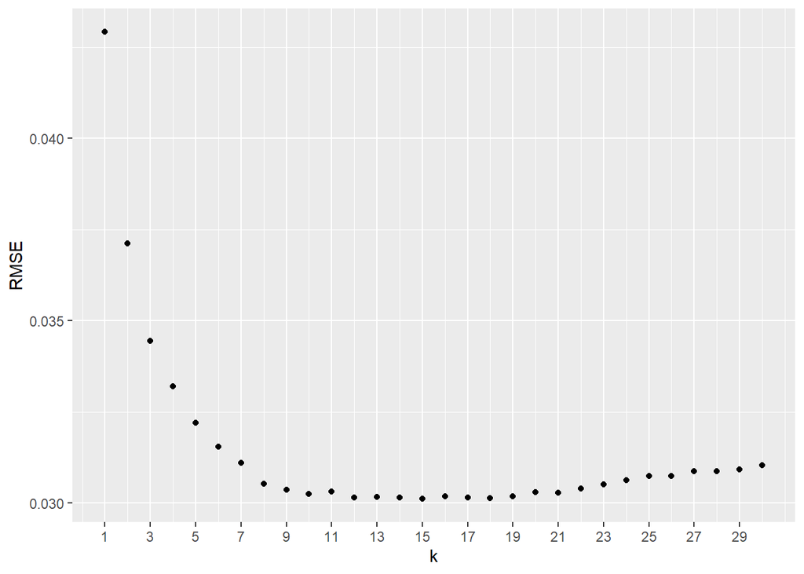

```r
ggplot(k_model$results,
aes(x = k,
y = RMSE)) +
geom_point() +
  scale_x_continuous("k", breaks = seq(1,30, by =2))
```

*Visualisation des résidus dans le jeu d’entrainement*

```r
# Prédiction avec les données du jeu d'entrainement
k_predict_train <- predict(k_model,train_recherche)
```

Pour rappel, les résidus sont les différences entre les valeurs observées et les valeurs approximées (prédites) par le modèle:

```r
#calcul des résidus pour le Knn sur le jeu d'entrainement
valeur_observe <- train_recherche$outcome
valeur_predite <- k_predict_train
residuel <- tibble(real_y = train_recherche$outcome, reste = train_recherche$outcome - valeur_predite)

head(residuel)
```

```
## # A tibble: 6 x 2
##   real_y    reste
##    <dbl>    <dbl>
## 1  0.944 -0.00817
## 2  0.913  0.0132
## 3  0.814  0.00183
## 4  0.672  0.0164
## 5  0.601  0.00314
## 6  0.961  0.00732
```

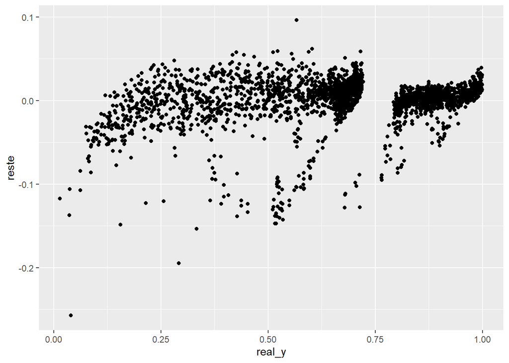

```r
#visualisation des résidus sur le jeu d'entrainement
ggplot(data=residuel,aes(x=real_y,y=reste)) +
  geom_point()
```

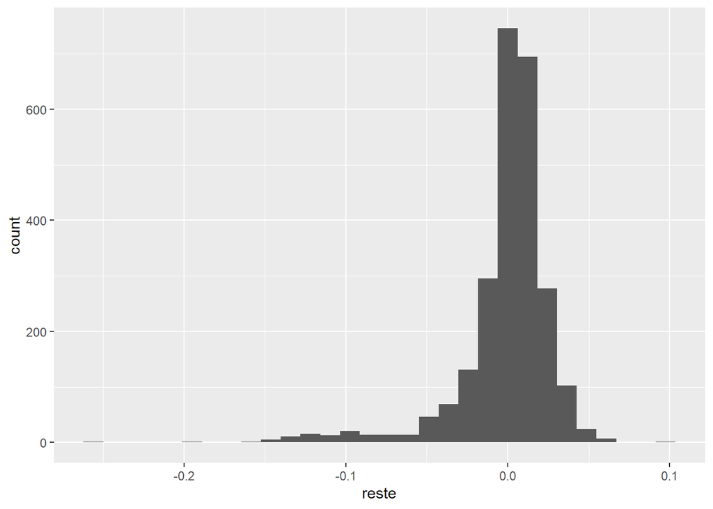

```r
#l’histogramme de la distribution des résidus:
ggplot(data=residuel, aes(x=reste))+
  geom_histogram()
```

## 2.3 Evaluation du modéle avec les données de test

```r
# Prédiction avec les données de test
k_predict_test <- predict(k_model,test_recherche)
str(k_predict_test)
```

```
##  num [1:1072] 0.695 0.656 0.418 0.681 0.672 ...
```

```r
#Puis, nous utilisons la fonction postResample pour calculer les métriques sur l’ensemble de test.
#postResample(pred = nnet_pred,
#obs = test_y_nnet)
# solTestY: les sorties du jeu de test;
k_RMSE <- postResample(pred = k_predict_test,
             obs = test_recherche$outcome)
k_RMSE
```

```
##       RMSE   Rsquared        MAE
## 0.03206535 0.98311990 0.01956260
```

La valeur du critére RMSE est légérement supérieure à celle calculée lors de la phase d’apprentissage

*Visualisation des résidus avec le jeu de données de test*

```r
#Pour rappel, les résidus sont les différences entre les valeurs observées et les valeurs
#approximées (prédites) par le modèle:

#calcul des résidus pour le Knn sur le jeu de tests
valeur_observe_test <- test_recherche$outcome
valeur_predite_test <- k_predict_test
residuel_test <- tibble(real_y = valeur_observe_test, reste = valeur_observe_test - valeur_predite_test)

head(residuel_test)
```

```
## # A tibble: 6 x 2
##   real_y    reste
##    <dbl>    <dbl>
## 1  0.694 -0.00103
## 2  0.533 -0.123
## 3  0.420  0.00198
## 4  0.674 -0.00681
## 5  0.682  0.0101
## 6  0.313  0.0192
```

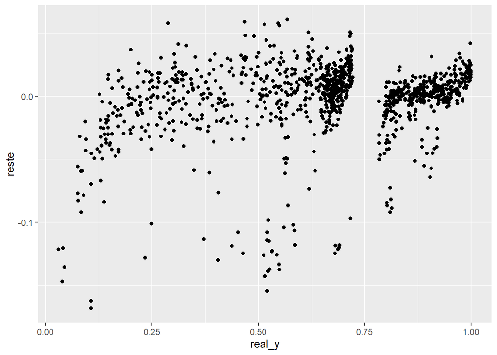

```r
#visualisation des résidus sur le jeu d'entrainement
ggplot(data=residuel_test,aes(x=real_y,y=reste)) +
  geom_point()
```

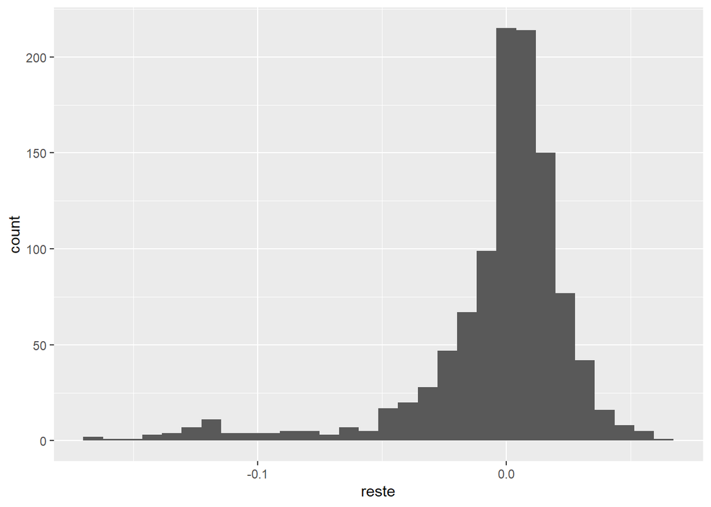

```r
#l’histogramme de la distribution des résidus:
ggplot(data=residuel_test, aes(x=reste))+
  geom_histogram()
```

Dans le diagramme histogramme, l’erreur semble bien distribuée autour de 0 de sorte qu’on sous-estime et surestime parfois la valeur

# 3 Deuxiéme modéle : Réseau de neurones.

Pour le deuxiéme modéle, nous choissisons d’utiliser les alogorithmes d’un réseau de neurones pour l’apprentissage

## 3.1 Entrainement

### 3.1.1 Paramétre du modéle d’apprentissage Réseau de neurones

Ici, on indique que nous souhaitons faire une validation croisée en 10 partitions (10-fold cross-validation). Selon la documentation de Caret, les paramétres possibles sont :

```r
#validation croisée en 10 partitions (10-fold cross-validation)
nn_control <- trainControl(method= "cv", number=10)

#nn_tune_grid = expand.grid(decay = c(0, 0.01, .1), size = c(1:5))

nn_tune_grid <-  expand.grid(decay = c(0, 0.01, .1),
                        size=c(0:10))
#Apprentissage :

nn_train_x <- select(train_recherche, -outcome)
nn_train_y <- train_recherche$outcome


nn_tune_grid2 <- expand.grid(size = seq(from = 1, to = 10, by = 1),
                       decay = seq(from = 0, to = 0.5, by = 0.1))
```

```r
nn_modele_rds_filename <- 'data/nn_modele_rds_filename.rds'
if(!file.exists(nn_modele_rds_filename)) {
  nn_model <- train(nn_train_x, nn_train_y,
                  trControl = nn_control,
                  method = 'nnet',
                  linout = TRUE,
                  preProc = c('center', 'scale'),
                  tuneGrid = nn_tune_grid2,
                  metric = 'RMSE'
                  )
write_rds(nn_model, nn_modele_rds_filename)
} else {
nn_model <- read_rds(nn_modele_rds_filename)
}


nn_model$bestTune
```

```
##    size decay
## 55   10     0
```

```r
nn_model$finalModel
```

```
## a 22-10-1 network with 241 weights
## inputs: in01 in02 in03 in04 in05 in06 in07 in08 in09 in10 in11 in12 in13 in14 in15 in16 in17 in18 in19 in20 in21 in22
## output(s): .outcome
## options were - linear output units
```

```r
postResample(pred = nn_model$finalModel$fitted.values,
            obs = nn_train_y)
```

```
##       RMSE   Rsquared        MAE
## 0.02463246 0.98914954 0.01119465
```

## 3.2 Évaluation avec les données d’entraiement

*Visualisation des résidus dans le jeu d’entrainement*

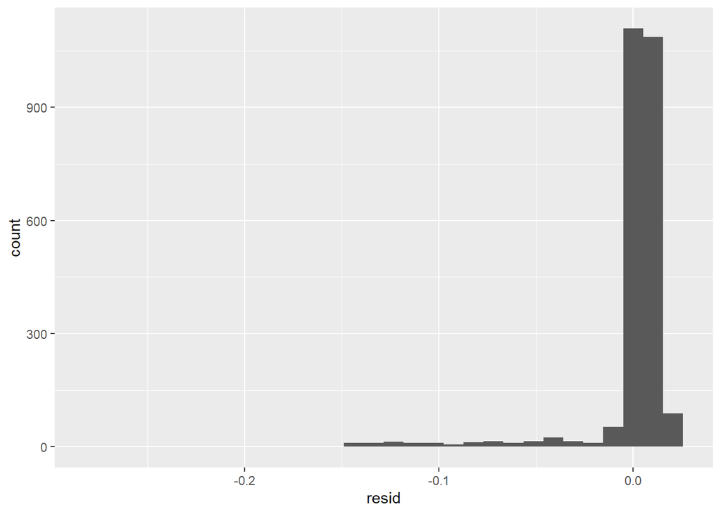

```r
# Graphique des résidus sur le jeu d'entrainement
ggplot(data = tibble(resid = nn_model$finalModel$residuals),
      aes(x = resid)) +
  geom_histogram()
```

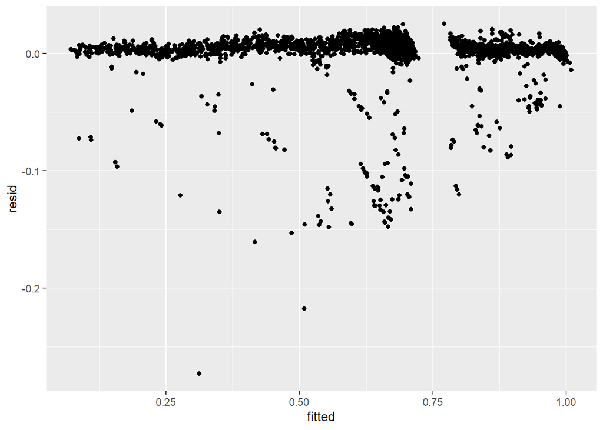

```r
nn_train_fitted_resid <- tibble(fitted = nn_model$finalModel$fitted.values,
resid = nn_model$finalModel$residuals)

ggplot(data = nn_train_fitted_resid,
      aes(x = fitted,
      y = resid)) +
  geom_point()
```

l’erreur est relativement bien distribuée autour de la droite en resid = 0. Le modèle semble à la fois faire des erreurs à la baisse et à la hausse.

## 3.3 Evaluation avec les données de test

*Affichage du modéle*

Les meilleurs parametres sont 10, 0

```r
# Prédiction avec les données de test
nn_predict_test <- predict(nn_model,test_recherche)
str(nn_predict_test)
```

```
##  num [1:1072, 1] 0.684 0.682 0.412 0.662 0.67 ...
##  - attr(*, "dimnames")=List of 2
##   ..$ : chr [1:1072] "1" "2" "3" "4" ...
##   ..$ : NULL
```

```r
#Puis, nous utilisons la fonction postResample pour calculer les métriques sur l’ensemble de test.

# solTestY: les sorties du jeu de test;
nn_RMSE <- postResample(pred = nn_predict_test,
             obs = test_recherche$outcome)
nn_RMSE
```

```
##       RMSE   Rsquared        MAE
## 0.02588051 0.98873662 0.01191445
```

La valeur RMSE est inférieure à celle du modéle Knn

*Visualisation des résidus avec le jeu de test*

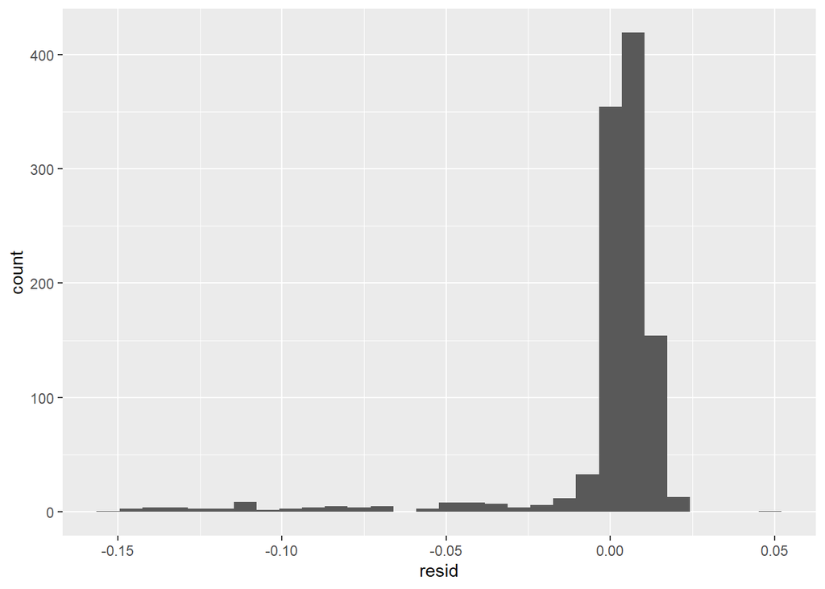

```r
# Cacul des résidus
nn_test_resid = valeur_observe_test - nn_predict_test

#Graphique en histogramme

ggplot(data = tibble(resid = nn_test_resid),
      aes(x = resid)) +
  geom_histogram()
```

```r
#Graphique nuage de point :

nn_residuel_test <- tibble(real_y = valeur_observe_test, reste = nn_test_resid)

head(nn_residuel_test)
```

```
## # A tibble: 6 x 2
##   real_y reste[,1]
##    <dbl>     <dbl>
## 1  0.694   0.00934
## 2  0.533  -0.149
## 3  0.420   0.00777
## 4  0.674   0.0121
## 5  0.682   0.0114
## 6  0.313   0.00991
```

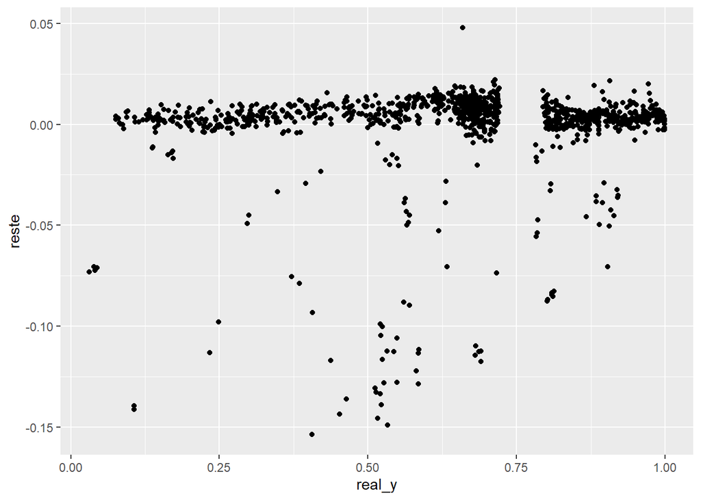

```r
#visualisation des résidus sur le jeu de test
ggplot(data=nn_residuel_test,aes(x=real_y,y=reste)) +
  geom_point()
```

```r
# visualisation prediction et valeur observée
nn_test_fitted_real <- tibble(real_y = valeur_observe_test,
                              pred_y = nn_predict_test)
```

# 4 Comparaison des deux modèles

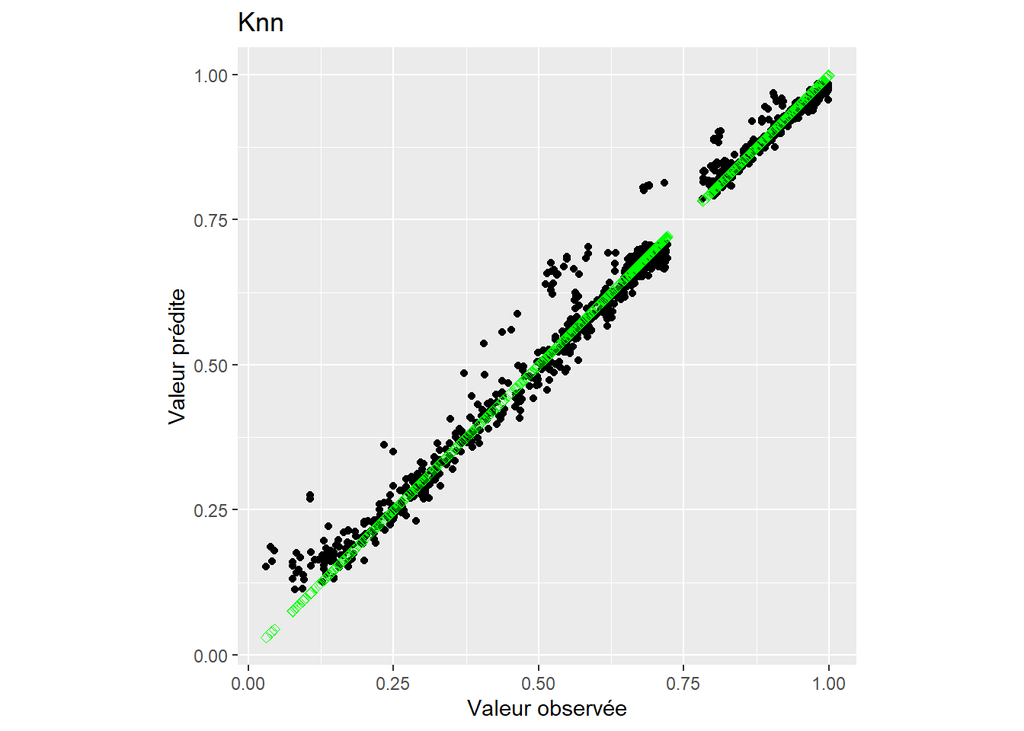

```r
k_test_fitted_real <- tibble(real_y = test_recherche$outcome,
                              pred_y = k_predict_test)
# Graphique Knn
ggplot(data = k_test_fitted_real,
aes(x = real_y,y = pred_y)) +
geom_point()+
geom_point(aes(x = real_y,
y = real_y),
color = 'green',
shape=5) +
coord_fixed()+
   labs(x = "Valeur observée", y = "Valeur prédite", title = "Knn")
```

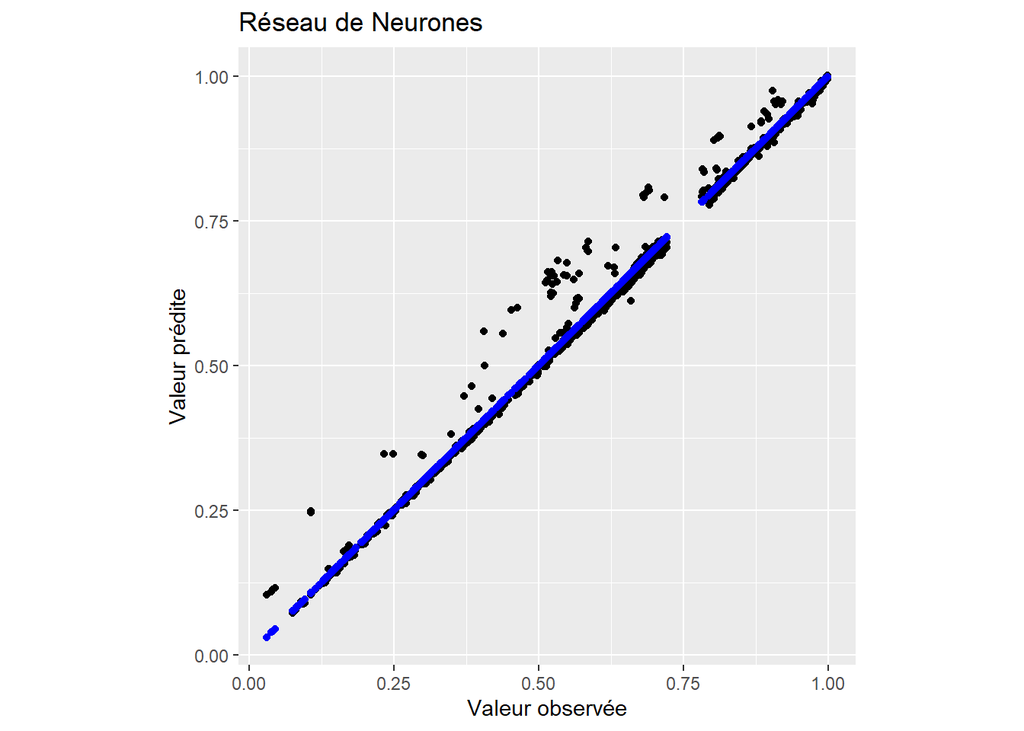

```r
# Graphique Réseau neurone
ggplot(data = nn_test_fitted_real,
  aes(x = real_y, y = pred_y)) +
  geom_point() +
  geom_point(aes(x = real_y, y= real_y),colour="blue") +
  coord_fixed() +
   labs(x = "Valeur observée", y = "Valeur prédite", title = "Réseau de Neurones")
```

Le critére qui a été choisi pour cette analyse en régression est le RMSE. Ce critére permet de calculer les erreurs d’estimation des 2 modéles.

Le modéle ayant la plus faible RMSE est le réseau de neurones comparativemeent au modéle Knn. Le modéle basé sur le reseau de neurones est donc le meilleur pour ce cas.

RMSE Réseau de neurone : 0.0258805, 0.9887366, 0.0119144 RMSE Knn : 0.0320653, 0.9831199, 0.0195626

Visuellement on peut oberver aussi que les résidus du réseau de neurones sont plus concentrés autour de la droite 0 qui est la droite parfaite, que ceux du modéle Knn.

```r
# Sauvegarde dans un fichier du meilleur modéle

best_modele_rds_filename <- 'data/best_modele_rds_filename.rds'
if(!file.exists(best_modele_rds_filename))
  {  best_model <- nn_model
      write_rds(best_model, best_modele_rds_filename)
  }
```

# 5 Compétition

## 5.1 Premier requis

Le nom du modéle en compéttion est TopduTop nom de fichier : Q1_challenger_T17_TopduTop.rds

## 5.2 Deuxième requis

```r
#Chargement du modéle challenger
top_modele_rds_filename <- 'data/Q1_challenger_T17_TopduTop.rds'


if(file.exists(top_modele_rds_filename)) {
  TopduTop <- read_rds(top_modele_rds_filename)

}

#Chargement des données pour la compétition
filename_competition <- 'data/data_competition.txt'
data_competition <- read_csv(filename_competition)

#Retire les valuers NA si il y en a :
data_competition <- na.omit(data_competition)
```

## 5.3 Troisième requis

```r
# Prédiction avec les données de compétition
competition_predict <- predict(TopduTop,data_competition)

#calcul de la RMSE
competition_RMSE <- postResample(pred = competition_predict,
             obs = data_competition$outcome)

#Affichage de la RMSE :
competition_RMSE
```

```
##       RMSE   Rsquared        MAE
## 0.02501313 0.98901425 0.01141043
```